# Assignment 7 - Repeated measure

Author

Micah Jones

# 1 Introduction

This assignment will ask you to conduct a repeated measure analysis.

For that, you will first need to watch (and code along with) the following repeated measure video:

- repeated measure lecture: https://youtu.be/-ANqcQhB–A?si=7YeeYqDgcLsj5erW&t=4268 (starts at 01:11:08, watch till the end, about 50 min)
- repeated measure lab part 1: https://youtu.be/GY2e-9M5bFM?si=TIw5F4EF2m9Dx5uK (watch full video, ~1h 50 min)
- repeated measure lab part 2: https://youtu.be/F3vg89ymLeM?si=Zv-RPIdS8mig4EMb (watch full video, ~2h)
- The partial script for the video above is in our GitHub repository, 04-classcode, **03-11_repeatedmeasure_partial.qmd**.
- The data set for this exercise is in oir GitHub repository, 03-classcode, **wheat_nk_balkh_rm.csv**.

**AFTER watching the video and developing the code in class**, then start working on this HW assignment.

# 2 Instructions

- Create on your GitHub a repo named `06_rm`.
- Clone it to your computer, create the necessary subfolders.
- Move the script **03-11_repeatedmeasure_partial.qmd** into the `code` subfolder.
- Move this script into the `code` subfolder
- Move the **wheat_nk_balkh_rm.csv** data set into the `data` subfolder
- On this script, fill your name under the `title` section of the YAML

# 3 Goal of this assignment

The goal is this assignment is for you to **learn about and conduct a full repeated measure analysis**.

Once you finish coding along with the videos, answer the following questions.

# 4 Questions

In class, we decided to use AIC as the metric to select the best model, and this determined the best model to be the one with a general error correlation matrix structure. If we had used BIC as the metric, then the model selected would have been the default model. Here, you are asked to use BIC and thus select the default model as the best, and perform all the steps after model selection. You may copy and paste the class script, and adapt the copied version to implement these changes.

## 4.1 Setup and Getting Residuals

### 4.1.1 Running All Models

```r
library(tidyverse) # for data wrangling and plotting
library(car) # for Anova function
library(lme4)
library(broom) # for model residuals extraction
library(emmeans) # for model mean extraction
library(multcomp) # for pairwise comparison letter display
library(nlme) # for repeated measure correlation structures
```

```r
rm_rcbd_df <- read.csv("../data/wheat_nk_balkh_rm.csv") %>%
  mutate(across(trt:splot, ~factor(.))) %>% #first argument selects columns, second specifies function, dot shows where to apply
  mutate(fdap = factor(dap))
```

```r
mod1_default <- lme(yield_kgha ~ krate_kgha*nrate_kgha*fdap,
                    random = ~ 1 | block/krate_kgha/nrate_kgha,
                          data = rm_rcbd_df,

                          )
```

```r
mod2_cs  <- lme(yield_kgha ~ krate_kgha*nrate_kgha*fdap,
                random = ~ 1 | block/krate_kgha/nrate_kgha,
                correlation = corCompSymm(form = ~dap), #for this, use numerical version of dap so that it can account for distance
                data = rm_rcbd_df

                          )
```

```r
mod3_gen <- lme(
  yield_kgha ~ krate_kgha*nrate_kgha*fdap,
  random = ~ 1|block/krate_kgha/nrate_kgha,
  correlation = corSymm(),
  data = rm_rcbd_df)
```

```r
mod4_ar1 <- lme(
  yield_kgha ~ krate_kgha*nrate_kgha*fdap,
  random = ~ 1|block/krate_kgha/nrate_kgha,
  correlation = corAR1(form = ~ dap),

  data = rm_rcbd_df)
```

```r
mod5_arma11 <- lme(
  yield_kgha ~ krate_kgha*nrate_kgha*fdap,
  random = ~ 1|block/krate_kgha/nrate_kgha,
  correlation = corARMA(p = 1,
                        q = 1),

  data = rm_rcbd_df)
```

```r
mod6_exp <- lme(
  yield_kgha ~ krate_kgha*nrate_kgha*fdap,
  random = ~ 1|block/krate_kgha/nrate_kgha,
  correlation = corExp(form = ~ dap),

  data = rm_rcbd_df)
```

```r
mod7_gaus <- lme(
  yield_kgha ~ krate_kgha*nrate_kgha*fdap,
  random = ~ 1|block/krate_kgha/nrate_kgha,
  correlation = corGaus(form = ~ dap),

  data = rm_rcbd_df)
```

```r
mod8_lin <- lme(
  yield_kgha ~ krate_kgha*nrate_kgha*fdap,
  random = ~ 1|block/krate_kgha/nrate_kgha,
  correlation = corLin(form = ~ dap),

  data = rm_rcbd_df)
```

```r
mod9_rq <- lme(
  yield_kgha ~ krate_kgha*nrate_kgha*fdap,
  random = ~ 1|block/krate_kgha/nrate_kgha,
  correlation = corRatio(form = ~ dap),

  data = rm_rcbd_df)
```

```r
mod10_sph <- lme(
  yield_kgha ~ krate_kgha*nrate_kgha*fdap,
  random = ~ 1|block/krate_kgha/nrate_kgha,
  correlation = corSpher(form = ~ dap),

  data = rm_rcbd_df)
```

### 4.1.2 Sorting Models By BIC

```r
anova(mod1_default,
      mod2_cs, mod3_gen, mod4_ar1, mod5_arma11,
      mod6_exp, mod7_gaus, mod8_lin, mod9_rq, mod10_sph) %>%
  as.data.frame() %>%
  rownames_to_column(var = "modelname") %>%
  janitor::clean_names() %>%
  dplyr::select(modelname, model, df, aic, bic) %>%
  arrange(bic)
```

```
      modelname model df      aic      bic
1  mod1_default     1 40 1257.397 1364.682
2     mod10_sph    10 41 1259.254 1369.221
3      mod8_lin     8 41 1259.254 1369.221
4     mod7_gaus     7 41 1259.254 1369.222
5      mod6_exp     6 41 1259.279 1369.246
6       mod9_rq     9 41 1259.321 1369.289
7       mod2_cs     2 41 1259.397 1369.364
8      mod4_ar1     4 41 1259.397 1369.364
9   mod5_arma11     5 42 1260.906 1373.555
10     mod3_gen     3 46 1255.668 1379.046
```

### 4.1.3 Checking Conditions for ANOVA

#### 4.1.3.1 Block Random Effects IID

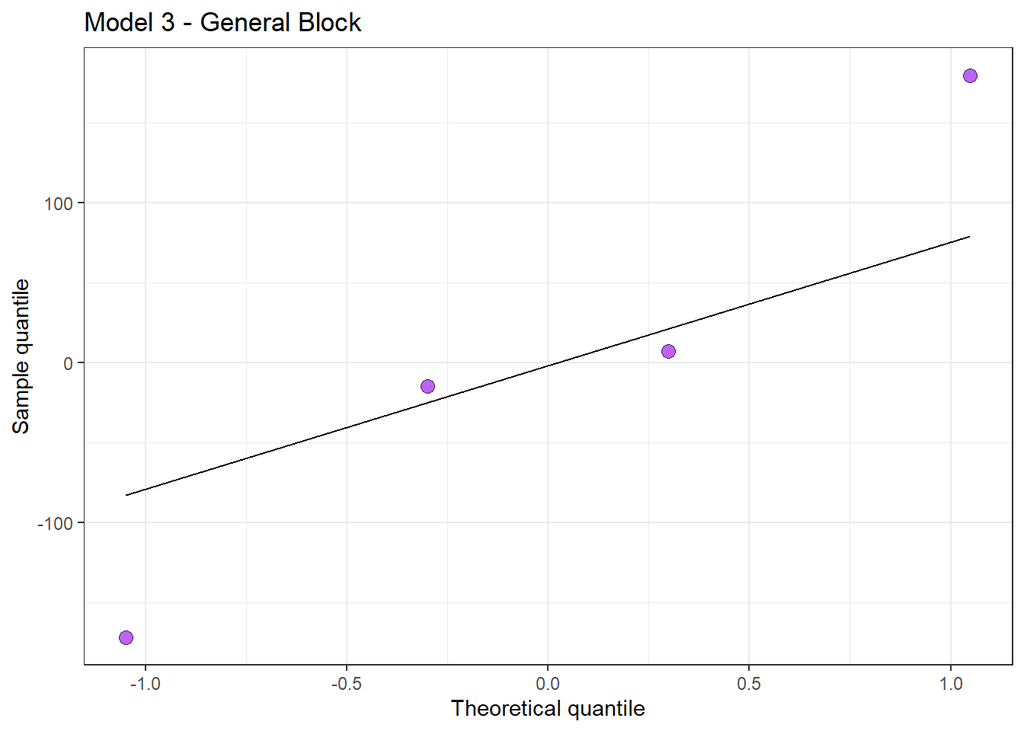

```r
ranef(mod3_gen)[[1]] %>%
  ggplot(aes(sample=`(Intercept)`))+
  stat_qq(  shape = 21,
            fill = "purple",
            size = 3,
            alpha = .7
  )+
  stat_qq_line()+
  labs(x = "Theoretical quantile",
       y = "Sample quantile",
       title = "Model 3 - General Block")+
  theme_bw()
```

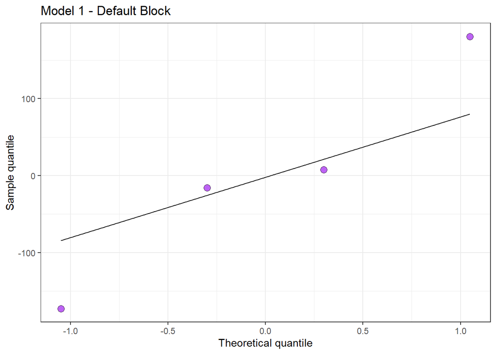

```r
ranef(mod1_default)[[1]] %>%
  ggplot(aes(sample=`(Intercept)`))+
  stat_qq(  shape = 21,
            fill = "purple",
            size = 3,
            alpha = .7
  )+
  stat_qq_line()+
  labs(x = "Theoretical quantile",
       y = "Sample quantile",
       title = "Model 1 - Default Block")+
  theme_bw()
```

The Default model has some deviation around the tails but generally looks fine. Does not appear to differ significantly from the General model plot.

#### 4.1.3.2 Block:KRate Random Effects IID

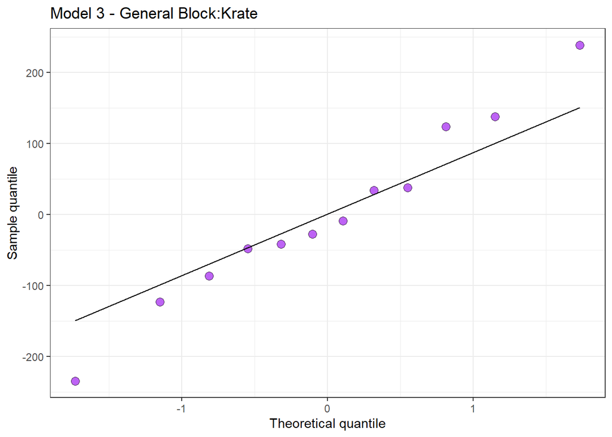

```r
ranef(mod3_gen)[[2]] %>%
  ggplot(aes(sample=`(Intercept)`))+
  stat_qq(  shape = 21,
            fill = "purple",
            size = 3,
            alpha = .7
  )+
  stat_qq_line()+
  labs(x = "Theoretical quantile",
       y = "Sample quantile",
       title = "Model 3 - General Block:Krate")+
  theme_bw()
```

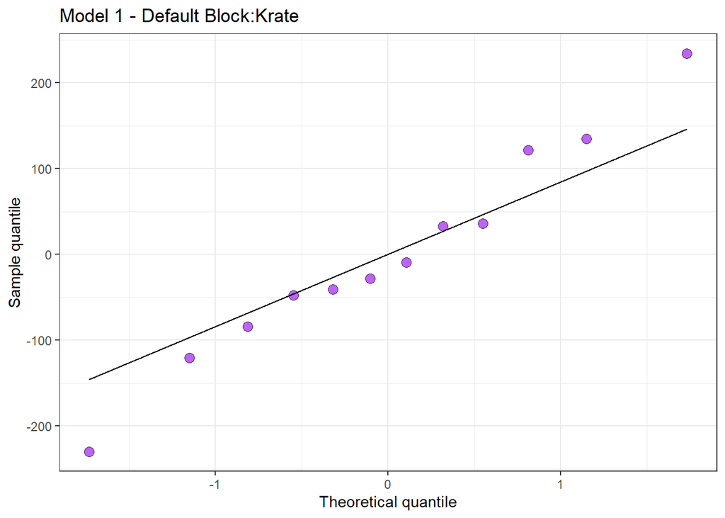

```r
ranef(mod1_default)[[2]] %>%
  ggplot(aes(sample=`(Intercept)`))+
  stat_qq(  shape = 21,
            fill = "purple",
            size = 3,
            alpha = .7
  )+
  stat_qq_line()+
  labs(x = "Theoretical quantile",
       y = "Sample quantile",
       title = "Model 1 - Default Block:Krate")+
  theme_bw()
```

Similarly to the first QQ plot, the Default model has some minor deviation around the tails but looks fine. Also does not differ substantially from the General model plot.

#### 4.1.3.3 Block:KRate:NRate Random Effects IID

[figure not shown]

```r
ranef(mod3_gen)[[3]] %>%
  ggplot(aes(sample=`(Intercept)`))+
  stat_qq(  shape = 21,
            fill = "purple",
            size = 3,
            alpha = .7
  )+
  stat_qq_line()+
  labs(x = "Theoretical quantile",
       y = "Sample quantile",
       title = "Model 3 - Default Block:Krate:Nrate")+
  theme_bw()
```

[figure not shown]

```r
ranef(mod1_default)[[3]] %>%
  ggplot(aes(sample=`(Intercept)`))+
  stat_qq(  shape = 21,
            fill = "purple",
            size = 3,
            alpha = .7
  )+
  stat_qq_line()+
  labs(x = "Theoretical quantile",
       y = "Sample quantile",
       title = "Model 1 - General Block:Krate:Nrate")+
  theme_bw()
```

Again, minor deviation around the tails, but nothing too concerning. The General model is again indistinguishable from the Default here.

## 4.2 Q1: Include here the residual assessment of the default model. Include each plot and its interpretation. How do these residuals from the default model visually compare to those from the general model?

### 4.2.1 Getting Residuals

```r
library(broom.mixed)

mod3_gen_resid <- augment(mod3_gen) %>%
  mutate(.stdresid=resid(mod3_gen,
                         type="pearson",
                         scaled=T))

mod3_gen_resid
```

```
# A tibble: 144 × 14
   trt   block nrate_kgha krate_kgha trtname wplot splot yield_kgha   dap fdap
   <fct> <fct> <fct>      <fct>      <fct>   <fct> <fct>      <int> <int> <fct>
 1 1     1     0          0          0+0     101   101-1       5488   120 120
 2 1     1     0          0          0+0     101   101-1       5898   130 130
 3 1     1     0          0          0+0     101   101-1       6133   140 140
 4 1     1     0          0          0+0     101   101-1       6151   150 150
 5 2     1     0          30         0+30    102   102-1       4448   120 120
 6 2     1     0          30         0+30    102   102-1       4842   130 130
 7 2     1     0          30         0+30    102   102-1       5057   140 140
 8 2     1     0          30         0+30    102   102-1       5094   150 150
 9 3     1     0          60         0+60    103   103-1       7445   120 120
10 3     1     0          60         0+60    103   103-1       7901   130 130
# ℹ 134 more rows
# ℹ 4 more variables: .fitted <dbl>, .resid <dbl>, .fixed <dbl>,
#   .stdresid <dbl>
```

```r
library(broom.mixed)

mod1_default_resid <- augment(mod1_default) %>%
  mutate(.stdresid=resid(mod1_default,
                         type="pearson",
                         scaled=T))

mod1_default_resid
```

```
# A tibble: 144 × 14
   trt   block nrate_kgha krate_kgha trtname wplot splot yield_kgha   dap fdap
   <fct> <fct> <fct>      <fct>      <fct>   <fct> <fct>      <int> <int> <fct>
 1 1     1     0          0          0+0     101   101-1       5488   120 120
 2 1     1     0          0          0+0     101   101-1       5898   130 130
 3 1     1     0          0          0+0     101   101-1       6133   140 140
 4 1     1     0          0          0+0     101   101-1       6151   150 150
 5 2     1     0          30         0+30    102   102-1       4448   120 120
 6 2     1     0          30         0+30    102   102-1       4842   130 130
 7 2     1     0          30         0+30    102   102-1       5057   140 140
 8 2     1     0          30         0+30    102   102-1       5094   150 150
 9 3     1     0          60         0+60    103   103-1       7445   120 120
10 3     1     0          60         0+60    103   103-1       7901   130 130
# ℹ 134 more rows
# ℹ 4 more variables: .fitted <dbl>, .resid <dbl>, .fixed <dbl>,
#   .stdresid <dbl>
```